# Image Inpainting

In this assignment, we implement a reduced image inpainting method inspired by the U-Net architecture and partial convolutions. The model is trained and evaluated on synthetically generated images derived from the DIV2K dataset, where irregular regions of the image are removed using randomly generated masks and reconstructed by the neural network.

```python
%env TORCHDYNAMO_DISABLE=1
import os
os.environ["TORCHDYNAMO_DISABLE"] = "1"
```

```
env: TORCHDYNAMO_DISABLE=1
```

```python
%pip install torchinfo
```

```python
import torch
from torch.utils import data
from torch.utils.data import Dataset, DataLoader
from torch import nn
import torch.nn.functional as F
import torch._dynamo as dynamo
dynamo.disable()
from torchinfo import summary
import os
import time
from PIL import Image
import random
import string
import cv2
import math
import numpy as np
import matplotlib.pyplot as plt
from functools import lru_cache
```

```python
device = torch.device("cuda") if torch.cuda.is_available() else torch.device("cpu")
```

```python
from google.colab import drive

drive.mount("/content/drive")

PROJECT_ROOT = "/content/drive/My Drive/NOS/V6"
CHECKPOINT_DIR = f"{PROJECT_ROOT}/checkpoints"

!mkdir -p PROJECT_ROOT

!mkdir -p CHECKPOINT_DIR

def save_model_to_drive(model, file_name):
    path = f"{PROJECT_ROOT}/{file_name}"
    torch.save(model.state_dict(), path)
    print("model saved:", path)

def save_checkpoint(model, optimizer, epoch):
    path = f"{CHECKPOINT_DIR}/unet_last.pt"
    torch.save(
        {
            "epoch": epoch,
            "model_state_dict": model.state_dict(),
            "optimizer_state_dict": optimizer.state_dict(),
        },
        path
    )
    print(f"[CHECKPOINT SAVED] {path} (epoch {epoch})")

def load_checkpoint(model_class, file_name, device):
    path = f"{CHECKPOINT_DIR}/{file_name}"
    model = model_class().to(device)
    model.load_state_dict(torch.load(path, map_location=device))
    return model

def set_seed(seed):
    random.seed(seed)
    np.random.seed(seed)
    torch.manual_seed(seed)
    if torch.cuda.is_available():
      torch.cuda.manual_seed_all(seed)
```

## Dataset Prep

### DIV2K

Source [Link](https://data.vision.ee.ethz.ch/cvl/DIV2K/)

```python
DRIVE_TRAIN = f"{PROJECT_ROOT}/dataset/train"
DRIVE_VAL   = f"{PROJECT_ROOT}/dataset/val"

LOCAL_ROOT = f"{CHECKPOINT_DIR}"
LOCAL_TRAIN = f"{LOCAL_ROOT}/train"
LOCAL_VAL   = f"{LOCAL_ROOT}/val"

os.makedirs(LOCAL_TRAIN, exist_ok=True)
os.makedirs(LOCAL_VAL, exist_ok=True)
os.makedirs(LOCAL_VAL, exist_ok=True)

def copy_if_needed(src, dst):
    if not os.path.isdir(src):
        raise FileNotFoundError(src)

    if len(os.listdir(dst)) >= len(os.listdir(src)):
        print(f"[OK] {dst} already populated")
        return

    print(f"[COPY] {src} -> {dst}")
    t0 = time.time()
    !rsync -ah "{src}/" "{dst}/"
    print(f"[DONE] {(time.time()-t0)/60:.1f} min")

copy_if_needed(DRIVE_TRAIN, LOCAL_TRAIN)

if os.path.isdir(DRIVE_VAL) and len(os.listdir(DRIVE_VAL)) > 0:
    copy_if_needed(DRIVE_VAL, LOCAL_VAL)
else:
    LOCAL_VAL = LOCAL_TRAIN

print("Using dataset from:", LOCAL_TRAIN)
```

```
[OK] /content/drive/My Drive/NOS/V6/checkpoints/train already populated
Using dataset from: /content/drive/My Drive/NOS/V6/checkpoints/train
```

```python
img_paths = [
    os.path.join(LOCAL_TRAIN, f)
    for f in os.listdir(LOCAL_TRAIN)
    if f.lower().endswith((".png", ".jpg", ".jpeg"))
]

print("Number of source images:", len(img_paths))
```

```
Number of source images: 800
```

```python
widths, heights = [], []
for p in img_paths:
    with Image.open(p) as im:
        w, h = im.size
    widths.append(w)
    heights.append(h)

print("Width:", min(widths), "-", max(widths))
print("Height:", min(heights), "-", max(heights))
```

```
Width: 558 - 1020
Height: 324 - 1020
```

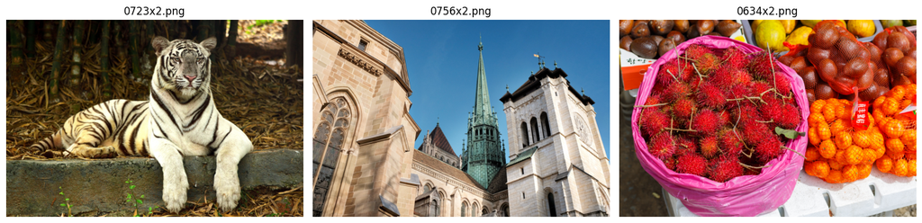

```python
def show_raw_images(paths, n=3):
    n = min(n, len(paths))
    chosen = random.sample(paths, n)

    fig, axes = plt.subplots(1, n, figsize=(5 * n, 4))
    if n == 1:
        axes = [axes]

    for ax, p in zip(axes, chosen):
        img = Image.open(p)
        ax.imshow(img)
        ax.set_title(os.path.basename(p))
        ax.axis("off")

    plt.tight_layout()
    plt.show()

show_raw_images(img_paths, n=3)
```

### Image Generation

Artificial training and test images are generated using random crops from the DIV2K dataset. For each image, a corresponding binary mask is created by drawing random thick lines, which represent missing regions in the image. The masked image is obtained by applying the mask to the original image.

#### Image gen utils

```python
@lru_cache(maxsize=512)
def read_rgb(path: str) -> np.ndarray:
    img = cv2.imread(path, cv2.IMREAD_COLOR)
    if img is None:
        raise RuntimeError(f"Failed to read: {path}")
    return cv2.cvtColor(img, cv2.COLOR_BGR2RGB)

def random_crop(img: np.ndarray, size: int) -> np.ndarray:
    h, w = img.shape[:2]

    if h < size or w < size:
        scale = max(size / h, size / w)
        img = cv2.resize(
            img,
            (int(round(w * scale)), int(round(h * scale))),
            interpolation=cv2.INTER_CUBIC
        )

    h, w = img.shape[:2]
    y = random.randint(0, h - size)
    x = random.randint(0, w - size)

    return img[y:y + size, x:x + size].copy()

def generate_random_mask(size=256):
    mask = np.ones((size, size), dtype=np.float32)

    num_segments = random.randint(3, 5)
    thickness = random.randint(12, 18)

    x, y = random.randint(0, size - 1), random.randint(0, size - 1)

    for _ in range(num_segments):
        dx = random.randint(-size // 2, size // 2)
        dy = random.randint(-size // 2, size // 2)

        x_new = np.clip(x + dx, 0, size - 1)
        y_new = np.clip(y + dy, 0, size - 1)

        cv2.line(mask, (x, y), (x_new, y_new), 0.0, thickness)

        x, y = x_new, y_new

    return mask

def apply_mask(img: np.ndarray, mask: np.ndarray):
    masked = img.copy()
    masked[mask == 0] = 0
    return masked
```

#### Dataset

```python
class SyntheticInpaintingDataset(Dataset):
    def __init__(self, img_paths, length, seed=None):
        self.img_paths = list(img_paths)
        self.length = int(length)
        self.seed = seed

    def __len__(self):
        return self.length

    def __getitem__(self, idx):
        if self.seed is not None:
            random.seed(self.seed + idx)

        img_path = random.choice(self.img_paths)
        img = read_rgb(img_path)
        img = random_crop(img, 256)

        mask = generate_random_mask(256)
        masked_img = apply_mask(img, mask)

        img = img.astype(np.float32) / 255.0
        masked_img = masked_img.astype(np.float32) / 255.0

        img = img.transpose(2, 0, 1)  # 3 x H x W
        masked_img = masked_img.transpose(2, 0, 1)
        mask = mask[None, ...]  # 1 x H x W

        return (
            torch.from_numpy(masked_img),
            torch.from_numpy(mask),
            torch.from_numpy(img)
        )
```

#### Batch

```python
def show_inpainting_examples(dataset: Dataset, n=5):
    fig, axes = plt.subplots(3, n, figsize=(3 * n, 7))

    for i in range(n):
        masked_img, mask, gt = dataset[i]

        masked_img = masked_img.permute(1, 2, 0).numpy()
        mask = mask[0].numpy()
        gt = gt.permute(1, 2, 0).numpy()

        axes[0, i].imshow(gt)
        axes[0, i].set_title("Original")
        axes[0, i].axis("off")

        axes[1, i].imshow(masked_img)
        axes[1, i].set_title("Masked image")
        axes[1, i].axis("off")

        axes[2, i].imshow(mask, cmap="gray")
        axes[2, i].set_title("Mask")
        axes[2, i].axis("off")

    plt.tight_layout()
    plt.show()
```

```python
train_ds = SyntheticInpaintingDataset(
    img_paths=img_paths,
    length=1024,
    seed=None
)

test_ds = SyntheticInpaintingDataset(
    img_paths=img_paths,
    length=1000,
    seed=123
)
```

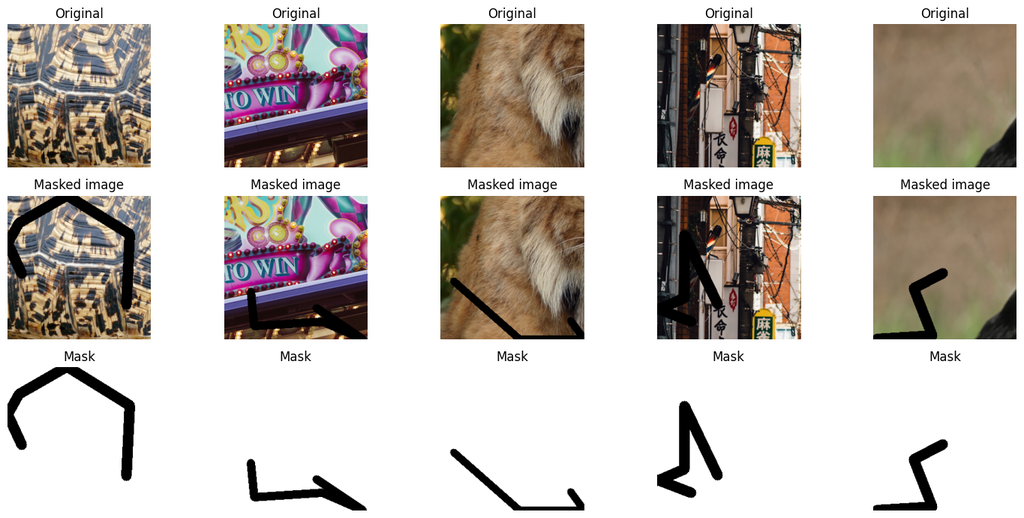

```python
show_inpainting_examples(train_ds, n=5)
```

## U-Net Model

The network architecture follows a simplified U-Net design with three downsampling and three upsampling stages, including skip connections between corresponding levels. Padding is used in all convolution layers to preserve spatial resolution.

```python
class PartialConv2d(nn.Module):
    def __init__(self, in_channels, out_channels, kernel_size=3, stride=1, padding=1):
        super().__init__()

        self.conv = nn.Conv2d(
            in_channels,
            out_channels,
            kernel_size,
            stride=stride,
            padding=padding,
            bias=False
        )

        self.register_buffer(
            "weight_mask",
            torch.ones(1, 1, kernel_size, kernel_size)
        )

        self.kernel_area = kernel_size * kernel_size
        self.stride = stride
        self.padding = padding

    def forward(self, x, mask):
        x = x * mask

        out = self.conv(x)

        with torch.no_grad():
            mask_sum = F.conv2d(
                mask,
                self.weight_mask,
                stride=self.stride,
                padding=self.padding
            )

        mask_new = (mask_sum > 0).float()

        out = out * (self.kernel_area / (mask_sum + 1e-8)) * mask_new

        return out, mask_new

class PartialBlock(nn.Module):
    def __init__(self, in_channels, out_channels, stride):
        super().__init__()

        self.pconv = PartialConv2d(
            in_channels,
            out_channels,
            kernel_size=3,
            stride=stride,
            padding=1
        )
        self.bn = nn.BatchNorm2d(out_channels)
        self.relu = nn.ReLU(inplace=True)

    def forward(self, x, mask):
        x, mask = self.pconv(x, mask)
        x = self.bn(x)
        x = self.relu(x)
        return x, mask
```

```python
class InpaintingUNet(nn.Module):
    def __init__(self):
        super().__init__()

        # Encoder
        self.enc1 = PartialBlock(3, 32, stride=1)
        self.enc2 = PartialBlock(32, 64, stride=2)
        self.enc3 = PartialBlock(64, 128, stride=2)

        # Bottleneck
        self.mid = PartialBlock(128, 128, stride=2)

        # Decoder
        self.up1 = nn.Upsample(scale_factor=2, mode="nearest")
        self.dec1 = PartialBlock(128 + 128, 64, stride=1)

        self.up2 = nn.Upsample(scale_factor=2, mode="nearest")
        self.dec2 = PartialBlock(64 + 64, 32, stride=1)

        self.up3 = nn.Upsample(scale_factor=2, mode="nearest")
        self.final = PartialConv2d(32 + 32, 3, kernel_size=3, stride=1, padding=1)

    def forward(self, x, mask):
        # Encoder
        e1, m1 = self.enc1(x, mask)
        e2, m2 = self.enc2(e1, m1)
        e3, m3 = self.enc3(e2, m2)

        # Bottleneck
        b, mb = self.mid(e3, m3)

        # Decoder
        d1 = self.up1(b)
        m1u = self.up1(mb)
        d1 = torch.cat([d1, e3], dim=1)
        m1u = torch.maximum(m1u, m3)
        d1, m1u = self.dec1(d1, m1u)

        d2 = self.up2(d1)
        m2u = self.up2(m1u)
        d2 = torch.cat([d2, e2], dim=1)
        m2u = torch.maximum(m2u, m2)
        d2, m2u = self.dec2(d2, m2u)

        d3 = self.up3(d2)
        m3u = self.up3(m2u)
        d3 = torch.cat([d3, e1], dim=1)
        m3u = torch.maximum(m3u, m1)

        out, _ = self.final(d3, m3u)

        # constrain output to valid RGB range
        out = torch.clamp(out, 0.0, 1.0)

        return out
```

```python
model = InpaintingUNet().to(device)

x = torch.randn(1, 3, 256, 256).to(device)
mask = torch.ones(1, 1, 256, 256).to(device)

y = model(x, mask)

print("Input:", x.shape)
print("Output:", y.shape)
```

```
Input: torch.Size([1, 3, 256, 256])
Output: torch.Size([1, 3, 256, 256])
```

```python
summary(
    model,
    input_data=(
        torch.randn(1, 3, 256, 256).to(device),
        torch.ones(1, 1, 256, 256).to(device)
    )
)
```

```
==========================================================================================
Layer (type:depth-idx)                   Output Shape              Param #
==========================================================================================
InpaintingUNet                           [1, 3, 256, 256]          --
├─PartialBlock: 1-1                      [1, 32, 256, 256]         --
│    └─PartialConv2d: 2-1                [1, 32, 256, 256]         --
│    │    └─Conv2d: 3-1                  [1, 32, 256, 256]         864
│    └─BatchNorm2d: 2-2                  [1, 32, 256, 256]         64
│    └─ReLU: 2-3                         [1, 32, 256, 256]         --
├─PartialBlock: 1-2                      [1, 64, 128, 128]         --
│    └─PartialConv2d: 2-4                [1, 64, 128, 128]         --
│    │    └─Conv2d: 3-2                  [1, 64, 128, 128]         18,432
│    └─BatchNorm2d: 2-5                  [1, 64, 128, 128]         128
│    └─ReLU: 2-6                         [1, 64, 128, 128]         --
├─PartialBlock: 1-3                      [1, 128, 64, 64]          --
│    └─PartialConv2d: 2-7                [1, 128, 64, 64]          --
│    │    └─Conv2d: 3-3                  [1, 128, 64, 64]          73,728
│    └─BatchNorm2d: 2-8                  [1, 128, 64, 64]          256
│    └─ReLU: 2-9                         [1, 128, 64, 64]          --
├─PartialBlock: 1-4                      [1, 128, 32, 32]          --
│    └─PartialConv2d: 2-10               [1, 128, 32, 32]          --
│    │    └─Conv2d: 3-4                  [1, 128, 32, 32]          147,456
│    └─BatchNorm2d: 2-11                 [1, 128, 32, 32]          256
│    └─ReLU: 2-12                        [1, 128, 32, 32]          --
├─Upsample: 1-5                          [1, 128, 64, 64]          --
├─Upsample: 1-6                          [1, 1, 64, 64]            --
├─PartialBlock: 1-7                      [1, 64, 64, 64]           --
│    └─PartialConv2d: 2-13               [1, 64, 64, 64]           --
│    │    └─Conv2d: 3-5                  [1, 64, 64, 64]           147,456
│    └─BatchNorm2d: 2-14                 [1, 64, 64, 64]           128
│    └─ReLU: 2-15                        [1, 64, 64, 64]           --
├─Upsample: 1-8                          [1, 64, 128, 128]         --
├─Upsample: 1-9                          [1, 1, 128, 128]          --
├─PartialBlock: 1-10                     [1, 32, 128, 128]         --
│    └─PartialConv2d: 2-16               [1, 32, 128, 128]         --
│    │    └─Conv2d: 3-6                  [1, 32, 128, 128]         36,864
│    └─BatchNorm2d: 2-17                 [1, 32, 128, 128]         64
│    └─ReLU: 2-18                        [1, 32, 128, 128]         --
├─Upsample: 1-11                         [1, 32, 256, 256]         --
├─Upsample: 1-12                         [1, 1, 256, 256]          --
├─PartialConv2d: 1-13                    [1, 3, 256, 256]          --
│    └─Conv2d: 2-19                      [1, 3, 256, 256]          1,728
==========================================================================================
Total params: 427,424
Trainable params: 427,424
Non-trainable params: 0
Total mult-adds (Units.GIGABYTES): 2.13
==========================================================================================
Input size (MB): 1.05
Forward/backward pass size (MB): 74.97
Params size (MB): 1.71
Estimated Total Size (MB): 77.73
==========================================================================================
```

## Learning

```python
def inpainting_loss(predicted, target, mask):
    hole = 1.0 - mask
    return ((predicted - target).abs() * hole).sum() / (hole.sum() + 1e-8)
```

```python
learning_rate = 1e-4
batch_size = 32
num_epochs = 100
images_per_epoch = 1024

optimizer = torch.optim.Adam(model.parameters(), lr=learning_rate)

train_loader = DataLoader(
    train_ds,
    batch_size=batch_size,
    shuffle=True,
    num_workers=4,
    pin_memory=True
)

val_loader = DataLoader(
    test_ds,
    batch_size=batch_size,
    shuffle=False,
    num_workers=4,
    pin_memory=True
)

@torch.no_grad()
def psnr_on_hole(pred, target, mask, eps=1e-8):
    hole = 1 - mask
    mse = ((pred - target) ** 2 * hole).sum() / (hole.sum() + eps)
    return 10 * math.log10(1.0 / (mse + eps))
```

```python
train_loss_history = []
val_loss_history = []
train_psnrs = []
val_psnrs = []

for epoch in range(num_epochs):
    model.train()
    train_loss = 0.0
    train_psnr = 0.0

    for masked, mask, img in train_loader:
        img = img.to(device)
        masked = masked.to(device)
        mask = mask.to(device)

        pred = model(masked, mask)
        loss = inpainting_loss(pred, img, mask)

        optimizer.zero_grad()
        loss.backward()
        optimizer.step()

        train_loss += loss.item()
        train_psnr += psnr_on_hole(pred, img, mask)

    train_loss /= len(train_loader)
    train_psnr /= len(train_loader)

    model.eval()
    val_loss = 0.0
    val_psnr = 0.0

    with torch.no_grad():
        for masked, mask, img in val_loader:
            img = img.to(device)
            masked = masked.to(device)
            mask = mask.to(device)

            pred = model(masked, mask)
            val_loss += inpainting_loss(pred, img, mask).item()
            val_psnr += psnr_on_hole(pred, img, mask)

    val_loss /= len(val_loader)
    val_psnr /= len(val_loader)

    train_loss_history.append(train_loss)
    val_loss_history.append(val_loss)
    train_psnrs.append(train_psnr)
    val_psnrs.append(val_psnr)

    print(
        f"Epoch [{epoch+1}/{num_epochs}] "
        f"Train loss: {train_loss:.4f}, Val loss: {val_loss:.4f}, "
        f"Train PSNR: {train_psnr:.2f}, Val PSNR: {val_psnr:.2f}"
    )

    if (epoch + 1) % 25 == 0:
        save_checkpoint(model, optimizer, epoch + 1)

save_model_to_drive(model, "inpainting_model.pt")
```

```
Epoch [1/100] Train loss: 0.8108, Val loss: 0.6836, Train PSNR: 4.59, Val PSNR: 6.00
Epoch [2/100] Train loss: 0.5550, Val loss: 0.4934, Train PSNR: 7.41, Val PSNR: 8.25
Epoch [3/100] Train loss: 0.4734, Val loss: 0.4299, Train PSNR: 8.58, Val PSNR: 9.30
Epoch [4/100] Train loss: 0.4213, Val loss: 0.3975, Train PSNR: 9.49, Val PSNR: 9.95
Epoch [5/100] Train loss: 0.4053, Val loss: 0.3705, Train PSNR: 9.86, Val PSNR: 10.40
Epoch [6/100] Train loss: 0.3819, Val loss: 0.3553, Train PSNR: 10.26, Val PSNR: 10.72
Epoch [7/100] Train loss: 0.3684, Val loss: 0.3402, Train PSNR: 10.52, Val PSNR: 11.01
Epoch [8/100] Train loss: 0.3544, Val loss: 0.3388, Train PSNR: 10.79, Val PSNR: 11.12
Epoch [9/100] Train loss: 0.3544, Val loss: 0.3356, Train PSNR: 10.87, Val PSNR: 11.22
Epoch [10/100] Train loss: 0.3407, Val loss: 0.3174, Train PSNR: 11.07, Val PSNR: 11.51
Epoch [11/100] Train loss: 0.3421, Val loss: 0.3244, Train PSNR: 11.08, Val PSNR: 11.38
Epoch [12/100] Train loss: 0.3248, Val loss: 0.3105, Train PSNR: 11.44, Val PSNR: 11.70
Epoch [13/100] Train loss: 0.3326, Val loss: 0.3057, Train PSNR: 11.21, Val PSNR: 11.76
Epoch [14/100] Train loss: 0.3199, Val loss: 0.3003, Train PSNR: 11.52, Val PSNR: 11.89
Epoch [15/100] Train loss: 0.3173, Val loss: 0.3051, Train PSNR: 11.59, Val PSNR: 11.79
Epoch [16/100] Train loss: 0.3150, Val loss: 0.2950, Train PSNR: 11.68, Val PSNR: 12.00
Epoch [17/100] Train loss: 0.3112, Val loss: 0.2878, Train PSNR: 11.62, Val PSNR: 12.15
Epoch [18/100] Train loss: 0.3028, Val loss: 0.2898, Train PSNR: 11.83, Val PSNR: 12.09
Epoch [19/100] Train loss: 0.3006, Val loss: 0.2944, Train PSNR: 11.98, Val PSNR: 12.06
Epoch [20/100] Train loss: 0.2998, Val loss: 0.2839, Train PSNR: 11.95, Val PSNR: 12.23
Epoch [21/100] Train loss: 0.2980, Val loss: 0.2782, Train PSNR: 11.99, Val PSNR: 12.31
Epoch [22/100] Train loss: 0.2953, Val loss: 0.2760, Train PSNR: 12.01, Val PSNR: 12.37
Epoch [23/100] Train loss: 0.2950, Val loss: 0.2764, Train PSNR: 12.06, Val PSNR: 12.38
Epoch [24/100] Train loss: 0.3049, Val loss: 0.2779, Train PSNR: 11.80, Val PSNR: 12.37
Epoch [25/100] Train loss: 0.2969, Val loss: 0.2792, Train PSNR: 12.01, Val PSNR: 12.32
[CHECKPOINT SAVED] /content/drive/My Drive/NOS/V6/checkpoints/unet_last.pt (epoch 25)
Epoch [26/100] Train loss: 0.2929, Val loss: 0.2751, Train PSNR: 12.07, Val PSNR: 12.45
Epoch [27/100] Train loss: 0.2809, Val loss: 0.2684, Train PSNR: 12.29, Val PSNR: 12.51
Epoch [28/100] Train loss: 0.2800, Val loss: 0.2658, Train PSNR: 12.36, Val PSNR: 12.58
Epoch [29/100] Train loss: 0.2886, Val loss: 0.2699, Train PSNR: 12.18, Val PSNR: 12.53
Epoch [30/100] Train loss: 0.2874, Val loss: 0.2657, Train PSNR: 12.13, Val PSNR: 12.57
Epoch [31/100] Train loss: 0.2837, Val loss: 0.2687, Train PSNR: 12.25, Val PSNR: 12.52
Epoch [32/100] Train loss: 0.2798, Val loss: 0.2679, Train PSNR: 12.39, Val PSNR: 12.58
Epoch [33/100] Train loss: 0.2796, Val loss: 0.2609, Train PSNR: 12.30, Val PSNR: 12.67
Epoch [34/100] Train loss: 0.2787, Val loss: 0.2654, Train PSNR: 12.40, Val PSNR: 12.64
Epoch [35/100] Train loss: 0.2813, Val loss: 0.2587, Train PSNR: 12.25, Val PSNR: 12.70
Epoch [36/100] Train loss: 0.2759, Val loss: 0.2575, Train PSNR: 12.40, Val PSNR: 12.73
Epoch [37/100] Train loss: 0.2758, Val loss: 0.2568, Train PSNR: 12.38, Val PSNR: 12.75
Epoch [38/100] Train loss: 0.2783, Val loss: 0.2587, Train PSNR: 12.41, Val PSNR: 12.70
Epoch [39/100] Train loss: 0.2788, Val loss: 0.2678, Train PSNR: 12.33, Val PSNR: 12.61
```

[output cut: 50 more lines]

```
Epoch [88/100] Train loss: 0.2584, Val loss: 0.2408, Train PSNR: 12.67, Val PSNR: 13.05
Epoch [89/100] Train loss: 0.2501, Val loss: 0.2368, Train PSNR: 12.91, Val PSNR: 13.08
Epoch [90/100] Train loss: 0.2485, Val loss: 0.2360, Train PSNR: 12.85, Val PSNR: 13.12
Epoch [91/100] Train loss: 0.2538, Val loss: 0.2359, Train PSNR: 12.69, Val PSNR: 13.11
Epoch [92/100] Train loss: 0.2505, Val loss: 0.2405, Train PSNR: 12.95, Val PSNR: 13.04
Epoch [93/100] Train loss: 0.2572, Val loss: 0.2376, Train PSNR: 12.69, Val PSNR: 13.08
Epoch [94/100] Train loss: 0.2524, Val loss: 0.2368, Train PSNR: 12.83, Val PSNR: 13.09
Epoch [95/100] Train loss: 0.2530, Val loss: 0.2376, Train PSNR: 12.83, Val PSNR: 13.04
Epoch [96/100] Train loss: 0.2548, Val loss: 0.2410, Train PSNR: 12.76, Val PSNR: 13.04
Epoch [97/100] Train loss: 0.2484, Val loss: 0.2359, Train PSNR: 12.84, Val PSNR: 13.10
Epoch [98/100] Train loss: 0.2456, Val loss: 0.2368, Train PSNR: 13.04, Val PSNR: 13.14
Epoch [99/100] Train loss: 0.2540, Val loss: 0.2369, Train PSNR: 12.78, Val PSNR: 13.07
Epoch [100/100] Train loss: 0.2629, Val loss: 0.2395, Train PSNR: 12.58, Val PSNR: 13.03
[CHECKPOINT SAVED] /content/drive/My Drive/NOS/V6/checkpoints/unet_last.pt (epoch 100)
model saved: /content/drive/My Drive/NOS/V6/inpainting_model.pt
```

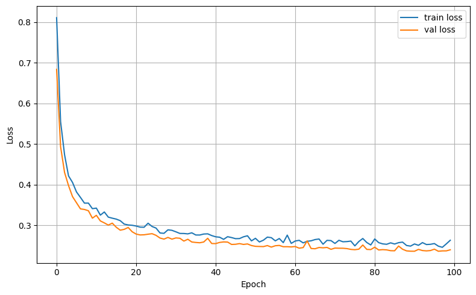

```python
plt.figure(figsize=(8, 5))
plt.plot(train_loss_history, label="train loss")
plt.plot(val_loss_history, label="val loss")
plt.xlabel("Epoch")
plt.ylabel("Loss")
plt.legend()
plt.grid(True)
plt.tight_layout()
plt.show()
```

## Testing

The trained model was evaluated on 1000 synthetically generated test images using MAE, MSE, and PSNR computed only on the missing (hole) regions. For each metric, the mean value and standard deviation are reported to assess both reconstruction quality and result stability.

```python
@torch.no_grad()
def evaluate_metrics(model, dataset, device, n_samples=1000):
    maes = []
    mses = []
    psnrs = []

    model.eval()

    for i in range(n_samples):
        masked, mask, img = dataset[i]

        img = img.unsqueeze(0).to(device)
        masked = masked.unsqueeze(0).to(device)
        mask = mask.unsqueeze(0).to(device)

        pred = model(masked, mask)
        hole = 1 - mask

        diff = pred - img

        mae = (diff.abs() * hole).sum() / (hole.sum() + 1e-8)
        mse = ((diff ** 2) * hole).sum() / (hole.sum() + 1e-8)
        psnr = 10 * torch.log10(1.0 / (mse + 1e-8))

        maes.append(mae.item())
        mses.append(mse.item())
        psnrs.append(psnr.item())

    return {
        "MAE_mean": np.mean(maes),
        "MAE_std": np.std(maes),
        "MSE_mean": np.mean(mses),
        "MSE_std": np.std(mses),
        "PSNR_mean": np.mean(psnrs),
        "PSNR_std": np.std(psnrs),
    }

metrics = evaluate_metrics(model, test_ds, device, n_samples=1000)

for k, v in metrics.items():
    print(f"{k}: {v:.4f}")
```

```
MAE_mean: 0.2423
MAE_std: 0.1203
MSE_mean: 0.0519
MSE_std: 0.0465
PSNR_mean: 14.7842
PSNR_std: 4.6616
```

```python
@torch.no_grad()
def evaluate_model(model, dataset, n_samples=1000):
    model.eval()

    losses = []

    for i in range(n_samples):
        masked_img, mask, gt = dataset[i]

        masked_img = masked_img.unsqueeze(0).to(device)
        mask = mask.unsqueeze(0).to(device)
        gt = gt.unsqueeze(0).to(device)

        pred = model(masked_img, mask)
        loss = inpainting_loss(pred, gt, mask)

        losses.append(loss.item())

    return np.mean(losses), np.std(losses)

mean_loss, std_loss = evaluate_model(model, test_ds, n_samples=1000)

print("Test loss mean:", mean_loss)
print("Test loss std:", std_loss)
```

```
Test loss mean: 0.24232622666633688
Test loss std: 0.12029699130576971
```

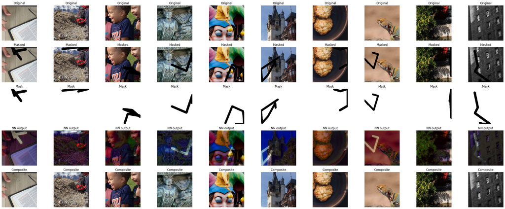

```python
def show_test_results(model, dataset, device, n=10):
    model.eval()

    fig, axes = plt.subplots(5, n, figsize=(3*n, 12))

    for i in range(n):
        masked, mask, img = dataset[i + 10]

        img_t = img.unsqueeze(0).to(device)
        masked_t = masked.unsqueeze(0).to(device)
        mask_t = mask.unsqueeze(0).to(device)

        with torch.no_grad():
            pred = model(masked_t, mask_t)

        img_np = img.permute(1, 2, 0).cpu().numpy()
        masked_np = masked.permute(1, 2, 0).cpu().numpy()
        mask_np = mask[0].cpu().numpy()
        pred_np = pred[0].permute(1, 2, 0).cpu().numpy()

        composite_np = pred_np * (1 - mask_np[..., None]) + img_np * mask_np[..., None]

        axes[0, i].imshow(img_np)
        axes[0, i].set_title("Original")
        axes[1, i].imshow(masked_np)
        axes[1, i].set_title("Masked")
        axes[2, i].imshow(mask_np, cmap="gray")
        axes[2, i].set_title("Mask")
        axes[3, i].imshow(pred_np)
        axes[3, i].set_title("NN output")
        axes[4, i].imshow(composite_np)
        axes[4, i].set_title("Composite")

        for r in range(5):
            axes[r, i].axis("off")

    plt.tight_layout()
    plt.show()

show_test_results(model, test_ds, device, n=10)
```

[figure not shown]

```python
model.eval()
masked_img, mask, gt = test_ds[123]

masked_img = masked_img.unsqueeze(0).to(device)
mask = mask.unsqueeze(0).to(device)
gt = gt.unsqueeze(0).to(device)

with torch.no_grad():
    pred = model(masked_img, mask)[0].cpu()

masked_img = masked_img[0].cpu()
gt = gt[0].cpu()
mask = mask[0, 0].cpu()

# Optional but safe: keep known pixels untouched
pred = pred * (1 - mask) + gt * mask

plt.figure(figsize=(12, 4))

plt.subplot(1, 4, 1)
plt.imshow(gt.permute(1, 2, 0))
plt.title("Original")
plt.axis("off")

plt.subplot(1, 4, 2)
plt.imshow(masked_img.permute(1, 2, 0))
plt.title("Masked image")
plt.axis("off")

plt.subplot(1, 4, 3)
plt.imshow(mask, cmap="gray")
plt.title("Mask")
plt.axis("off")

plt.subplot(1, 4, 4)
plt.imshow(pred.permute(1, 2, 0))
plt.title("Model output")
plt.axis("off")

plt.tight_layout()
plt.show()
```